# Coursework Report

*N* removed NAs: 3

*N* removed typo: 1

*N* removed <18: 30

*N* total clean: 116

| Group | *N* | *M*<sub>age</sub> | *M*<sub>rating</sub> |
| --- | --- | --- | --- |
| Control | 62 | 20.7 | 6.10 |
| Experim | 54 | 20.9 | 7.51 |

**Main analysis results**

*t*(114) = -9.25, *p* < .001

[interactive chart not shown]

[figure not shown]

[interactive chart not shown]

# Coursework Report

Analysing Data, Spring 2020

# Methods

## Participants

3 participants were also removed from this final sample, this is due to incomplete data or missing values. Below shows the revised participant’s descriptives.

**Figure 1: Descriptive statistics by participant age**

| *M*<sub>age</sub> | *SD*<sub>age</sub> | Minimum age | Maximum age |
| --- | --- | --- | --- |
| 20.8 | 2.04 | 18 | 25 |

## Design

The study aimed to examine the effect colour has on perceived attractiveness. The colours (categorical) will be red (experimental) and white (control). The colour white is used due to its neutral hues.

Perceived attractiveness (the dependent variable) will be operationalised using 3 face-valid questions, rated on a 9-point likert scale, e.g 1 (*not attractive*) to 9 (*very attractive*). These questions were “*How attractive do you think this person is?*”, “*How pleasant is this person to look at?*” and the statement “*If I were to meet this person in this picture, I would think he is attractive*”. These 3 scores were then averaged to form a composite score for each participant. In order to operationalise the image, each participant viewed the same black and white photo of a Caucasian man (4" x 6“) on an 8.5” x 11" piece of paper, with only the colour background changing in each experimental group.

I hypothesize that participants in the experimental (red colour) condition will give a higher composite score of attractiveness than those in the control (white colour) condition. To examine this operational hypothesis, I will conduct an independent-samples *t* test.

# Results

**Figure 2: Summary of mean attractiveness scores by condition**

| group | Item 1 *M* | Item 1 *SD* | Item 2 *M* | Item 2 *SD* | Item 3 *M* | Item 3 *SD* |
| --- | --- | --- | --- | --- | --- | --- |
| control | 6.34 | 1.10 | 6.13 | 1.35 | 5.84 | 1.30 |
| experimental | 7.54 | 1.41 | 7.61 | 1.43 | 7.37 | 1.25 |

The analysis conducted indicated that there was a significant difference in the mean attractiveness ratings of the control (white group) vs experimental (red group). Attractiveness scores were (*M*<sub>white</sub> = 6.102 and *M*<sub>red</sub> 7.506. 95% CI = [-1.7,-1.1]. The difference in mean scores was significant, (*M*<sub>diff</sub>) = -1.404. *T score* = (114) = -9.25. *P* < .001) which indicates strong evidence against the null hypothesis. Therefore, the results obtained support the original hypothesis that colour influences attraction scores.

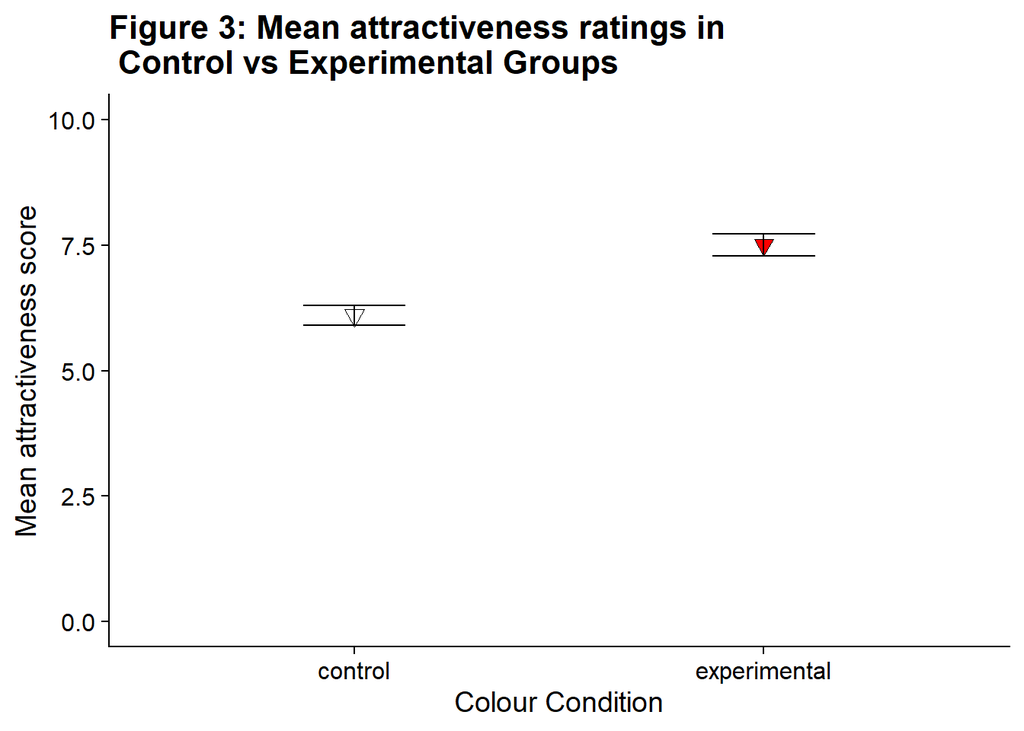

# Discussion

The *t* score was (114) = -9.25, meaning the difference between our sample means (`-1.404`) is 9.25 times greater than the *SD* of the difference in means. The *t* test shows there is a statistically significant difference between our experimental group means, and as the *P* value is <0.001, it is very unlikely the sample means have come from the same population. In conclusion, it is possible the two means came from different populations, and this is reflected in the analysis which suggests colour has a significant influence composite attraction scores.

Many other studies have explored the ‘red effect’ with varying results. In one experiment by Pazda, Elliot & Greitemeyer (2012), an independent samples *t* test also revealed colour having an affect on perceived attraction. In this experiment, researchers looked at male impressions of a woman, in contrast to Elliot et al (2010) which focussed on women observing a picture of a man. It is important to note that whilst Pazda, Elliot & Greitemeyer’s (2012) study may provide empirical evidence for a relationship between colour and attraction, it does not show the origins of the so called ‘red effect’, either biological or cultural/societal. In addition to this, the study looked at male’s perceptions on attraction, these findings would be hard to generalise to my own replication, as gender differences in perceived attraction / susceptibility to the colour red may be present.

In a study by Hellsinger, Goldbach & Carbon (2015), the basic experiment used by Elliot et. Al (2010) was replicated. The same photo was used from the original experiment, with the same 3 item questions. Results showed that participants in both conditions gave comparable ratings of attractiveness, with no differences being statistically significant. In a further study by Peperkoom, Roberts & Pollet (2016), two scenarios (short term and long term dating) were implemented to assess mating motivations. It was hypothesized that women in red would be considered more *sexually* attractive. However, results were inconsistent with these predictions, and the woman in red was not considered to be more sexually (or otherwise) attractive than the woman in other conditions.

Empirical evidence for the red effect has been disputed through literature, with some replications, such as those from Hellsinger, Goldbach & Carbon (2015), showing no evidence for it. However, other research finds support for the red effect. Such as an experiment by Roberts, Owen & Havlicek (2010), which demonstrated evidence for the red-attractiveness effect, but also a black-attractiveness effect. Even Elliot himself, found that when the original study was replicated with a larger sample, differences in colour and attraction scores fell short of statistical significance (Elliot & Maier 2013). The inconsistent nature of these findings leaves questions about measures used to obtain results, and whether the ‘red effect’ can be reliably demonstrated.

### Limitations

Whilst my analysis shows significant differences in the red and white colour conditions, and supports the original study by Elliot et al (2010), I believe there are some crucial limitations which should be addressed. Elliot and Maier (2013) agree with Francis’s (2013) critiques that the original study was under powered, with a small sample size. In my own replication, the sample size was larger (116 participants), but still smaller than the sample used for replications by Elliot and Maier (2013), which found no red effect.

The design of my own replication has its own strengths and limitations. On one hand, the design is easily replicable, with good operationalisation of variables, through 3 item attraction scores, and replicable study images. Yet, the design may fail to recognise the complexities of attraction and underpinning mechanisms behind it. Although my results show a small p-value, which suggests strong evidence for my hypothesis, it only means something if the attraction scores *actually measure* what they’re aiming to, attraction. It is known that attraction is a complex process, Robert, Owens & Havlicek (2010) have theorized through their own results that the colour effect may at least be partly due to subtle cues emitted from the wearer, such as posture and head-tilt.

### Future research

One area for future research could be to look at the influence the colour has on the wearer, as discussed by Robert, Owens and Havlicek (2010). Early research has suggested that even when colour was cropped out of the image shown to participants, males photographed whilst wearing red received higher attraction scores. In order to investigate this effect further, observational field research could be used to look at colour in a real life setting. In addition to this, researchers could instead use videos of targets wearing colours, and show these to participants instead of standardized pictures. This would enable participants to see any cues emitted from wearers. In order to test whether it is these cues that influence attraction, these videos could be digitally altered to display a different colour than red to the participants, and measure if this still has the ‘red effect’. Carrying out observational studies come at the cost of introducing potential confounding variables, but I would argue that the currently used method of lab research for the ‘red effect’ is lacking somewhat in ecological validity.

An additional further area for research could be to investigate the influence of age and hormones on attraction. In many of the studies discussed (including my own replication), participants have been young, and at peak fertility. Some research has suggested that hormones may play an influential role in perceptions of the colour red. Eisenbruch, Simmons, & Roney (2015) found women who were ovulating at the time of the experiment, were more likely to wear the colour red. In order to fully explore the ‘red effect’, it would be beneficial to use samples with a range of ages, including pre and post menopausal, for comparison. In a study by Schwarz & Singer (2013), the red effect was pronounced only for young targets, who were perceived to be in their twenties.

Both of these areas for research aim to establish the mechanisms behind the ‘red effect’. On one hand, researching cues emitted from wearers investigates an environmental/contextual cause to the effect, and would help researchers understand attraction from a ‘real life’ perspective. On the other hand, investigating age and colour/attraction would look into the potential biological causes. Both of these areas of research could be carried out together, that is, carrying out observational research with participants with a wide age range. The reasons behind the ‘red effect’, if it exists, could be both biological and environmental, and so far no researcher has underpinned these causes.

To conclude, my replication supports the research from the original Elliot et al (2010) study, suggesting some sort of ‘red effect’ is present within the experimental design used. However, the context in which the ‘red effect’ has been displayed has been limited, and researchers can only speculate what causes it. To address these limitations, I have suggested two areas for future research, which aim to investigate the ‘red effect’ as both a biological and contextual mechanism.

# References

Eisenbruch, A. B., Simmons, Z. L., & Roney, J. R. (2015). Lady in Red: Hormonal Predictors of Women’s Clothing Choices. *Psychological Science, 26(8), 1332–1338*.

Elliot, A. J., Niesta Kayser, D., Greitemeyer, T., Lichtenfeld, S., Gramzow, R. H., Maier, M. A., & Liu, H. (2010). Red, rank, and romance in women viewing men. *Journal of Experimental Psychology: General, 139(3), 399*.

Elliot, A., & Maier, M. (2013). The Red-Attractiveness Effect, Applying the Ioannidis and Trikalinos (2007b) Test, and the Broader Scientific Context: A Reply to Francis (2013). *Journal of Experimental Psychology, 142(1), 297-300*.

Francis, G. (2013). Publication Bias in “Red, Rank, and Romance in Women Viewing Men,” by Elliot Et Al. (2010). *Journal of Experimental Psychology, 142(1), 292-296*.

Hesslinger, V., Goldbach, M., & Carbon, L. (2015). Men in red: A reexamination of the red-attractiveness effect. *Psychonomic Bulletin & Review, 22(4), 1142-1148*.

Pazda, A., Elliot, A., & Greitemeyer, T. (2012). Sexy red: Perceived sexual receptivity mediates the red-attraction relation in men viewing woman. *Journal of Experimental Social Psychology, 48(3), 787-790*.

Peperkoorn, L., Roberts, S., & Pollet, T. (2016). Revisiting the Red Effect on Attractiveness and Sexual Receptivity: No Effect of the Color Red on Human Mate Preferences. *Evolutionary Psychology, 14(4), 1-13*.

Roberts, S., Owen, R., & Havlicek, J. (2010). Distinguishing between Perceiver and Wearer Effects in Clothing Color-Associated Attributions. *Evolutionary Psychology, 8(3), 350-364*.

Schwarz, S., & Singer, M. (2013). Romantic red revisited: Red enhances men’s attraction to young, but not menopausal women. *Journal of Experimental Social Psychology, 49(1), 161-164*.